# #Returns #Facts #Plots #Macro-Finance

Bryan Routledge

2024.01.08 (updated)

# A few facts and plots - Financial Returns Data

Finance is a quantitative science – we are looking to explain **quantities** of financial data. For example, not just that risk premiums are positive but their magnitude. The equity risk premium is 6% and that is a bug number,

#### Load Libraries

Loading libraries (If you need help loading libraries, let me know.)

```r
if("tidyverse" %in% installed.packages() == FALSE) {install.packages("tidyverse")}
if("tidyquant" %in% installed.packages() == FALSE) {install.packages("tidyquant")}
if("zoo" %in% installed.packages() == FALSE) {install.packages("zoo")}
if("gt" %in% installed.packages() == FALSE) {install.packages("gt")}
```

```r
# Load Data and few libs
library("tidyverse")
library("tidyquant")
library("lubridate")
library("zoo")
library("gt")  # use "gt" instead of print for tables

# Bryan specific ones
source("bryan_lib.R")
source("returns_lib.R")
```

#### Data

This is data from Ken French data page. This is the ``Fama-French’’ (FF) data. He pulls from CRSP and has a broad set of portfolios that are the standard test-bed portfolios to use in finance (macro-finance).

Note the FF data comes as ``simple’’ returns. I have converted them to continously compounded returns.

- In the data R_n is: $r_{n,t+1} = log(P_{n,t+1}+d_{t+1})-log(P_{n,t})$ (where n is Market, I_coal, … etc. )
- Excess returns is the return above the risk free rate (one month t-bill is what is used in FF). in the data these are denoted eR_Market and eR_n is: $r_{n,t+1}- r_{f,t+1}$
- Usually it is better to work with eR_n. This item tends to look a bit more stationary in the data and is connected to theroy nicely – The average eR_n is the main object of attention.

I have a script that pulls this from the page and dumps it in a csv file. You should be able to get the FF data straight into R. See:

- https://rviews.rstudio.com/2018/04/11/introduction-to-fama-french/
- There has to be better options!

#### Load Monthly Data

```r
Data <- read_csv(file="http://gerbil.life/47721/data/FF.Data.Monthly.csv")
Meta <- Make.Meta(Data)
Meta %>% gt
```

| T.start | T.max | N.obs | Period |
| --- | --- | --- | --- |
| 1926-07-31 | 2023-11-30 | 1169 | Monthly |

Note this data is organized in a “panel” (like a spreadsheet) and not in a long list. I now know (always be learning), R works better with things in a “long” format. So on my agenda is updating code to do that. I will keep you posted

## Risk Premium - (Unconditional)

- The stock market has big returns and is volatile.
- The risk free rate is small and is not volatile.
- Note the risk free rate here is nominal. So it includes expected inflation. We can re-do this with real rates and it is a number <1% per year.

```r
R.stats<-Calc.R.stats(what=c("R_Market","R_Rf"),X=Data,sharpe.calc=FALSE)
n<-Real.cols(R.stats)
R.stats %>% gt %>% fmt_number(columns = all_of(n), decimals = 4)
```

| portfolio | mean.er.annual | sig.er.annual | t.0 | t.T | mean | sd | min | max | n.obs |
| --- | --- | --- | --- | --- | --- | --- | --- | --- | --- |
| R_Market | 0.0956 | 0.1847 | 1926-07-31 | 2023-11-30 | 0.0080 | 0.0533 | −0.3439 | 0.3289 | 1169 |
| R_Rf | 0.0320 | 0.0087 | 1926-07-31 | 2023-11-30 | 0.0027 | 0.0025 | −0.0006 | 0.0134 | 1169 |

Note the risk-free rate moves around a fair bit. Most of this is due to inflation

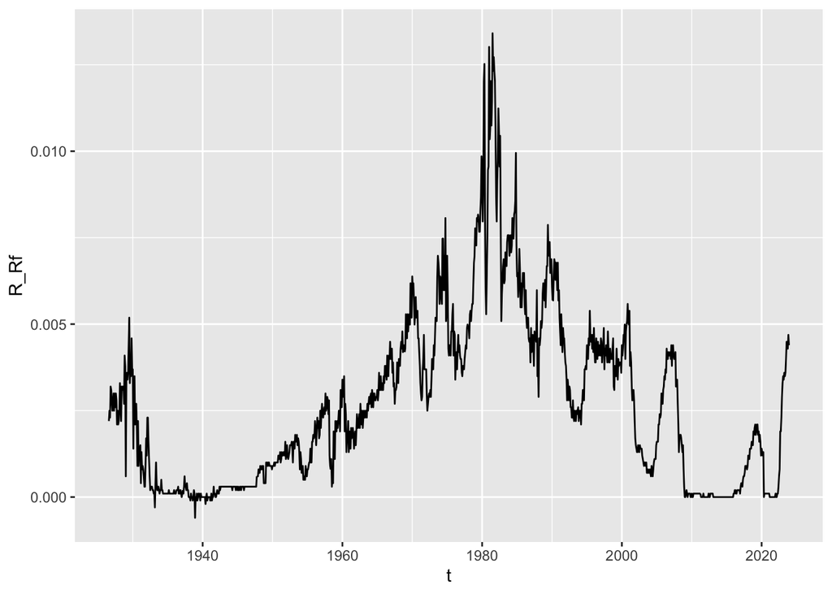

```r
p<- ggplot(data=Data)
p<- p + geom_line(aes(x=t,y=R_Rf))
p
```

#### The Equity risk premium is big!

- Don’t we need a quantitative model to say that? YES! we do.
- Here we look at EXCESS returns: $r_{t+1,market}-r_{t+1,risk-free}$. In my data I have these named “eR_*“. Here the risk-free rate is the 1 month t-bill. Note this removes (mostly) the impact of inflation since inflation expectations would be in both R_market and R_Rf. This also makes the data more”stationary”.
- Estimating it is hard. The big volatility in the data means it is a hard number to estimate.
- The ball park number I use is 6% with a vol of 20%

```r
R.stats<-Calc.R.stats(what=c("eR_Market"),X=Data)
n<-Real.cols(R.stats)
R.stats %>% gt %>% fmt_number(columns = n, decimals = 4)
```

| portfolio | mean.er.annual | sig.er.annual | Sharpe.annual | t.0 | t.T | mean | sd | min | max | n.obs |
| --- | --- | --- | --- | --- | --- | --- | --- | --- | --- | --- |
| eR_Market | 0.0636 | 0.1850 | 0.3438 | 1926-07-31 | 2023-11-30 | 0.0053 | 0.0534 | −0.3442 | 0.3279 | 1169 |

```r
R.stats<-bind_rows(R.stats,
  Calc.R.stats(start="19520101",what=c("eR_Market"),X=Data),
  Calc.R.stats(start="19520101",end="20081231",what=c("eR_Market"),X=Data),
  Calc.R.stats(start="20000101",what=c("eR_Market"),X=Data),

)


R.stats %>% gt %>% fmt_number(columns = n, decimals = 4)
```

| portfolio | mean.er.annual | sig.er.annual | Sharpe.annual | t.0 | t.T | mean | sd | min | max | n.obs |
| --- | --- | --- | --- | --- | --- | --- | --- | --- | --- | --- |
| eR_Market | 0.0636 | 0.1850 | 0.3438 | 1926-07-31 | 2023-11-30 | 0.0053 | 0.0534 | −0.3442 | 0.3279 | 1169 |
| eR_Market | 0.0635 | 0.1519 | 0.4178 | 1952-01-31 | 2023-11-30 | 0.0053 | 0.0438 | −0.2627 | 0.1486 | 863 |
| eR_Market | 0.0486 | 0.1498 | 0.3245 | 1952-01-31 | 2008-12-31 | 0.0041 | 0.0432 | −0.2627 | 0.1486 | 684 |
| eR_Market | 0.0513 | 0.1616 | 0.3174 | 2000-01-31 | 2023-11-30 | 0.0043 | 0.0467 | −0.1889 | 0.1280 | 287 |

#### Invest $1

One way to see that this is ``big’’ (without a model, just yet) is to look at investing $1 in a buy-and-hold strategy. That is just roll it over.

The risk-free rate keeps you about on-par with incflation. The stock market gets you $11,000+. The ``stocks for the long run’’ in one chart.

To calculate this, it is easy. With continuously compounded returns, the $\log(W_{n,T}) = \sum_{t=0}^T r_{n,t}$. Just a sum of the returns on portfolio $n$ to date. This is because, $W_{n,t+1}=W_{n,t} \exp(r_{n,t+1})$.

(This is such a common plot – you use it all the time when you are teaching finance – that I made a function to calculate this. That is my “One.Dollar” function.)

```r
one.dollar<-One.Dollar(what=c("R_Rf","R_Market"),end.only=TRUE)
one.dollar<-bind_rows(
  one.dollar,
  One.Dollar(what=c("R_Rf","R_Market"),start="19520101",end.only=TRUE)
)
one.dollar<-bind_rows(
  one.dollar,
  One.Dollar(what=c("R_Rf","R_Market"),start="20000101",end.only=TRUE)
)

one.dollar %>% gt %>% fmt_number(columns = c(logW), decimals = 2) %>%
  fmt_currency(columns = c(W), currency="USD")
```

| Portfolio | t.0 | t.T | W | logW |
| --- | --- | --- | --- | --- |
| R_Rf | 1926-07-31 | 2023-11-30 | $22.64 | 3.12 |
| R_Market | 1926-07-31 | 2023-11-30 | $11,100.33 | 9.31 |
| R_Rf | 1952-01-01 | 2023-11-30 | $17.62 | 2.87 |
| R_Market | 1952-01-01 | 2023-11-30 | $1,689.34 | 7.43 |
| R_Rf | 2000-01-01 | 2023-11-30 | $1.47 | 0.39 |
| R_Market | 2000-01-01 | 2023-11-30 | $5.02 | 1.61 |

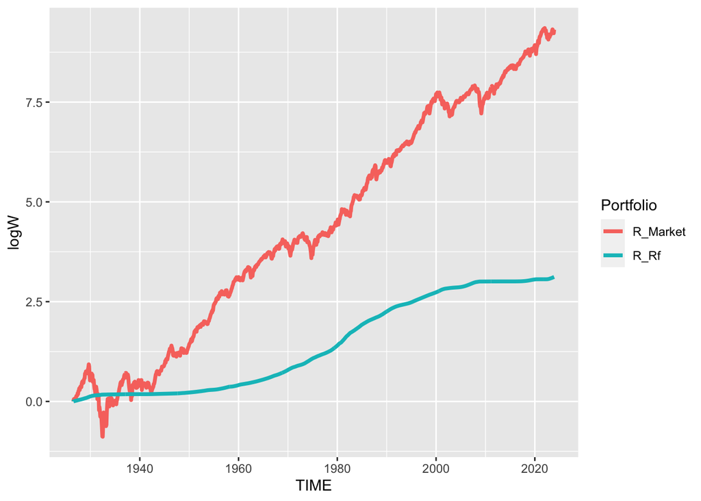

```r
p <- ggplot()+geom_line(data= One.Dollar(what=c("R_Rf","R_Market")) ,
            aes(x=TIME,y=logW,color=Portfolio),size=1.3)
print(p)
```

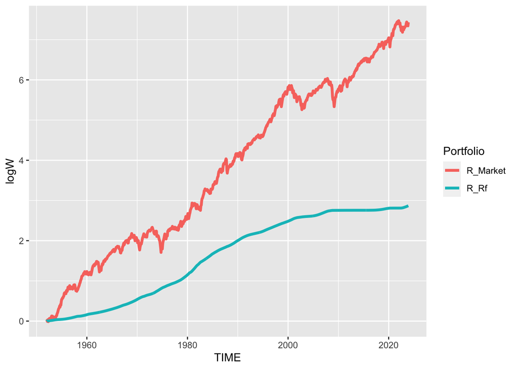

```r
p <- ggplot()+geom_line(data= One.Dollar(what=c("R_Rf","R_Market"),start="19520101") ,
            aes(x=TIME,y=logW,color=Portfolio),size=1.3)
print(p)
```

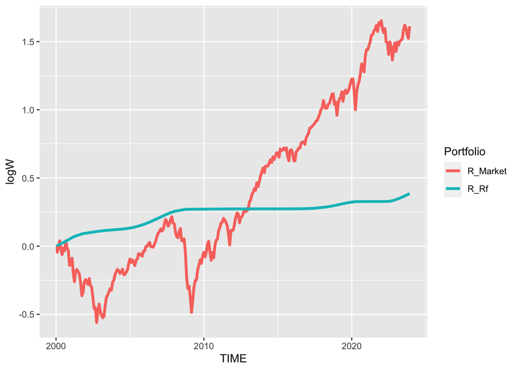

```r
p <- ggplot()+geom_line(data= One.Dollar(what=c("R_Rf","R_Market"),start="20000101") ,
            aes(x=TIME,y=logW,color=Portfolio),size=1.3)
print(p)
```

```r
Best.Worst(Flag.Year = 2020,N=12) %>% gt %>% fmt_number(columns = c(R), decimals = 1, scale_by = 100, pattern="{x}%")
```

| TIME | Portfolio | R | h | flag |
| --- | --- | --- | --- | --- |
| 1931-09-30 | R_Market | −34.4% | Worst |  |
| 1938-03-31 | R_Market | −27.2% | Worst |  |
| 1987-10-31 | R_Market | −25.7% | Worst |  |
| 1940-05-31 | R_Market | −24.8% | Worst |  |
| 1932-05-31 | R_Market | −22.9% | Worst |  |
| 1929-10-31 | R_Market | −21.9% | Worst |  |
| 1932-04-30 | R_Market | −19.7% | Worst |  |
| 2008-10-31 | R_Market | −18.8% | Worst |  |
| 1930-06-30 | R_Market | −17.4% | Worst |  |
| 1998-08-31 | R_Market | −17.0% | Worst |  |
| 1933-02-28 | R_Market | −16.6% | Worst |  |
| 1937-09-30 | R_Market | −14.6% | Worst |  |
| 1933-06-30 | R_Market | 12.3% | Best |  |
| 2020-04-30 | R_Market | 12.8% | Best | **** |
| 1931-06-30 | R_Market | 13.1% | Best |  |
| 1975-01-31 | R_Market | 13.3% | Best |  |
| 1938-04-30 | R_Market | 13.6% | Best |  |
| 1974-10-31 | R_Market | 15.4% | Best |  |
| 1939-09-30 | R_Market | 15.6% | Best |  |
| 1933-05-31 | R_Market | 19.4% | Best |  |
| 1938-06-30 | R_Market | 21.4% | Best |  |
| 1932-07-31 | R_Market | 29.2% | Best |  |
| 1932-08-31 | R_Market | 31.5% | Best |  |
| 1933-04-30 | R_Market | 32.9% | Best |  |

## Cross-Section

The second big quantative thing is the cross-section of risk-premiums. Why do some portfolios have higher or lower expected returns?

#### Industry

```r
R.stats<-Calc.R.stats(what.pattern  =c("eR_I"), what=c("eR_Market"),
                      start="19520101",
                      X=Data) %>% arrange(mean.er.annual)
# Other is a goofy category; drop for now
R.stats <- R.stats %>% filter(portfolio !="eR_I_Other")

# Pick some interesting ones - top and bottom
Bot<-R.stats %>% select(portfolio) %>% head(n=5) %>% pull
Top<-R.stats %>% select(portfolio) %>% tail(n=5) %>% pull

n<-Real.cols(R.stats)
R.stats %>% filter(portfolio %in% c(Bot,"eR_Market",Top)) %>% gt %>% fmt_number(columns = n, decimals = 4)
```

| portfolio | mean.er.annual | sig.er.annual | Sharpe.annual | t.0 | t.T | mean | sd | min | max | n.obs |
| --- | --- | --- | --- | --- | --- | --- | --- | --- | --- | --- |
| eR_I_Gold | 0.0061 | 0.3537 | 0.0173 | 1963-07-31 | 2023-11-30 | 0.0005 | 0.1021 | −0.4103 | 0.5805 | 725 |
| eR_I_Softw | 0.0087 | 0.3729 | 0.0234 | 1965-07-31 | 2023-11-30 | 0.0007 | 0.1076 | −0.4503 | 0.5465 | 701 |
| eR_I_FabPr | 0.0161 | 0.2724 | 0.0591 | 1963-07-31 | 2023-11-30 | 0.0013 | 0.0786 | −0.4124 | 0.3019 | 725 |
| eR_I_RlEst | 0.0283 | 0.2586 | 0.1093 | 1952-01-31 | 2023-11-30 | 0.0024 | 0.0747 | −0.4589 | 0.5020 | 863 |
| eR_I_Steel | 0.0309 | 0.2615 | 0.1182 | 1952-01-31 | 2023-11-30 | 0.0026 | 0.0755 | −0.3925 | 0.2638 | 863 |
| eR_Market | 0.0635 | 0.1519 | 0.4178 | 1952-01-31 | 2023-11-30 | 0.0053 | 0.0438 | −0.2627 | 0.1486 | 863 |
| eR_I_MedEq | 0.0789 | 0.1877 | 0.4204 | 1952-01-31 | 2023-11-30 | 0.0066 | 0.0542 | −0.2343 | 0.2134 | 863 |
| eR_I_Drugs | 0.0798 | 0.1692 | 0.4718 | 1952-01-31 | 2023-11-30 | 0.0067 | 0.0488 | −0.2179 | 0.2713 | 863 |
| eR_I_Fun | 0.0806 | 0.2633 | 0.3060 | 1952-01-31 | 2023-11-30 | 0.0067 | 0.0760 | −0.3905 | 0.3454 | 863 |
| eR_I_Meals | 0.0816 | 0.2074 | 0.3932 | 1952-01-31 | 2023-11-30 | 0.0068 | 0.0599 | −0.3854 | 0.2468 | 863 |
| eR_I_Smoke | 0.0940 | 0.2030 | 0.4632 | 1952-01-31 | 2023-11-30 | 0.0078 | 0.0586 | −0.2910 | 0.2802 | 863 |

#### Invest $ - using eR

The invest $1 plot shows how wealth grows if you invest in portfolio $n$.  
Here, in this plot, we are using excess returns, so we are calculating $\log(W_{i,T}) = \sum_{t=0}^T (r_{i,t}-r_{f,t})$. So think of this as the extra wealth you have above investing in the risk-free rate. Since the risk-free rate is so small, the plots give us the same information.

(I have fudged “NA” here to “0” so the plot works. Some of these portfolios are not defined until later in the sample)

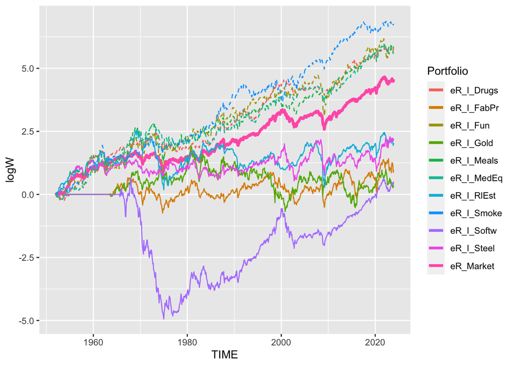

```r
p <- ggplot()
p <- p + geom_line(data= One.Dollar(what=c("eR_Market"),start="19520101",make.na.zero = TRUE) ,
            aes(x=TIME,y=logW,color=Portfolio),size=1.3)
p <- p + geom_line(data= One.Dollar(what=c(Bot), start="19520101",make.na.zero = TRUE) ,
            aes(x=TIME,y=logW,color=Portfolio),linetype="solid")
p <- p + geom_line(data= One.Dollar(what=c(Top), start="19520101",make.na.zero = TRUE) ,
            aes(x=TIME,y=logW,color=Portfolio),linetype="dashed")
print(p)
```

#### Characteristics

If you build portfolios based on observable characteristics (like market cap or book assets), you generate portfolios that highlight the cross sectional differences.

- Size – market capitalization
- BEME – Book equity / market capitaliztion
- Momentum – buy stocks that went up last month …

```r
# Just do this for everything
# this generates some warning/errors. Some of thes columns are missing etc.
R.stats<-Calc.R.stats(what.pattern = NULL,
                     what=c("eR_Size_Hi10","eR_Size_Lo10",
                            "eR_BEME_Hi10","eR_BEME_Lo10",
                            "eR_Mom_High","eR_Mom_Low"),
                      start="19520101",
            X=Data) %>% arrange(mean.er.annual) %>% arrange(portfolio)

R.stats %>% gt %>% fmt_number(columns = n, decimals = 4)
```

| portfolio | mean.er.annual | sig.er.annual | Sharpe.annual | t.0 | t.T | mean | sd | min | max | n.obs |
| --- | --- | --- | --- | --- | --- | --- | --- | --- | --- | --- |
| eR_BEME_Hi10 | 0.0852 | 0.2107 | 0.4042 | 1952-01-31 | 2023-11-30 | 0.0071 | 0.0608 | −0.4238 | 0.2600 | 863 |
| eR_BEME_Lo10 | 0.0571 | 0.1733 | 0.3294 | 1952-01-31 | 2023-11-30 | 0.0048 | 0.0500 | −0.2642 | 0.2000 | 863 |
| eR_Mom_High | 0.1201 | 0.2057 | 0.5838 | 1952-01-31 | 2023-11-30 | 0.0100 | 0.0594 | −0.3177 | 0.1927 | 863 |
| eR_Mom_Low | −0.0397 | 0.2728 | −0.1454 | 1952-01-31 | 2023-11-30 | −0.0033 | 0.0788 | −0.3295 | 0.3707 | 863 |
| eR_Size_Hi10 | 0.0602 | 0.1456 | 0.4136 | 1952-01-31 | 2023-11-30 | 0.0050 | 0.0420 | −0.2259 | 0.1609 | 863 |
| eR_Size_Lo10 | 0.0686 | 0.2113 | 0.3248 | 1952-01-31 | 2023-11-30 | 0.0057 | 0.0610 | −0.3466 | 0.2542 | 863 |

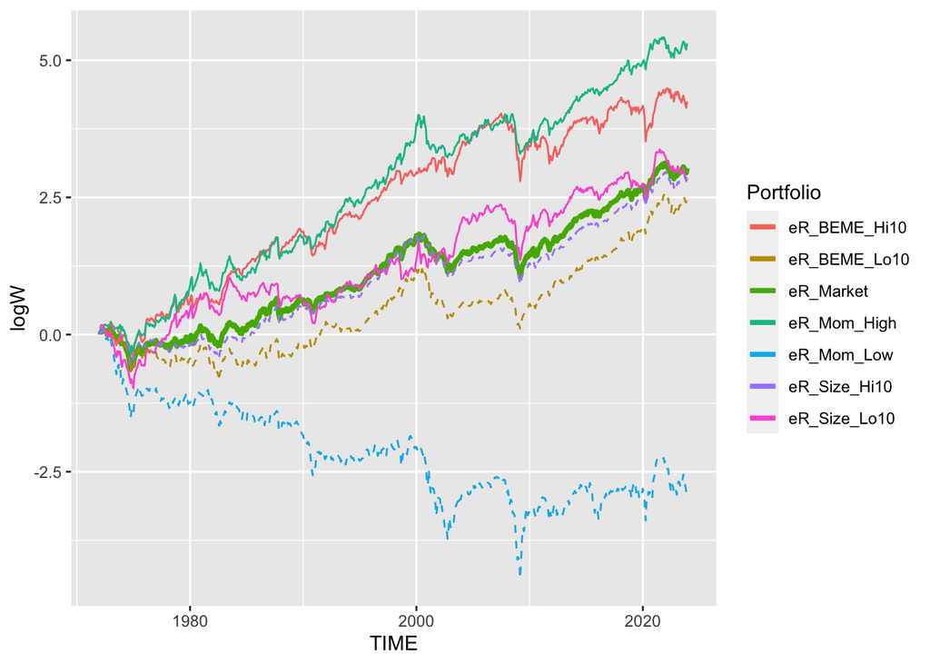

```r
p <- ggplot()
p <- p + geom_line(data= One.Dollar(what=c("eR_Market"),start="19720101") ,
            aes(x=TIME,y=logW,color=Portfolio),size=1.3)
p <- p + geom_line(data= One.Dollar(what=c("eR_Mom_High","eR_Size_Lo10","eR_BEME_Hi10"), start="19720101") ,
            aes(x=TIME,y=logW,color=Portfolio),linetype="solid")
p <- p + geom_line(data= One.Dollar(what=c("eR_Mom_Low","eR_Size_Hi10","eR_BEME_Lo10"), start="19720101") ,
            aes(x=TIME,y=logW,color=Portfolio),linetype="dashed")
print(p)
```

#### Load Daily Data

(loading this from a web page is a bit slow. Save the file to your own machine to make it faster)

```r
Data <- read_csv(file="http://gerbil.life/47721/data/FF.Data.Daily.csv")
Meta <- Make.Meta(Data)
Meta %>% gt
```

| T.start | T.max | N.obs | Period |
| --- | --- | --- | --- |
| 1926-07-01 | 2023-11-30 | 25629 | Daily |

## Returns and Risk-Premiums

Things look about the same.

- In here I am anualizing to annual data assuming 250 trading days per year
- AND! iid returns…. This assumption is not horrible for macro-like measurements. But it is not great (see the vol discussion below)

```r
R.stats<-Calc.R.stats(what=c("R_Market","R_Rf"),X=Data,sharpe.calc=FALSE)
n<-Real.cols(R.stats)
R.stats %>% gt %>% fmt_number(columns = n, decimals = 4)
```

| portfolio | mean.er.annual | sig.er.annual | t.0 | t.T | mean | sd | min | max | n.obs |
| --- | --- | --- | --- | --- | --- | --- | --- | --- | --- |
| R_Market | 0.0909 | 0.1712 | 1926-07-01 | 2023-11-30 | 0.0004 | 0.0108 | −0.1913 | 0.1464 | 25629 |
| R_Rf | 0.0304 | 0.0019 | 1926-07-01 | 2023-11-30 | 0.0001 | 0.0001 | 0.0000 | 0.0006 | 25629 |

```r
R.stats<-Calc.R.stats(what=c("eR_Market"),X=Data)
R.stats<-bind_rows(R.stats,
  Calc.R.stats(start="19520101",what=c("eR_Market"),X=Data),
  Calc.R.stats(start="19520101",end="20081231",what=c("eR_Market"),X=Data),
  Calc.R.stats(start="20000101",what=c("eR_Market"),X=Data),

)
R.stats %>% gt %>% fmt_number(columns = n, decimals = 4)
```

| portfolio | mean.er.annual | sig.er.annual | Sharpe.annual | t.0 | t.T | mean | sd | min | max | n.obs |
| --- | --- | --- | --- | --- | --- | --- | --- | --- | --- | --- |
| eR_Market | 0.0605 | 0.1712 | 0.3534603 | 1926-07-01 | 2023-11-30 | 0.0002 | 0.0108 | −0.1916 | 0.1463 | 25629 |
| eR_Market | 0.0629 | 0.1542 | 0.4078283 | 1952-01-02 | 2023-11-30 | 0.0003 | 0.0098 | −0.1916 | 0.1075 | 18122 |
| eR_Market | 0.0482 | 0.1442 | 0.3340735 | 1952-01-02 | 2008-12-31 | 0.0002 | 0.0091 | −0.1916 | 0.1075 | 14368 |
| eR_Market | 0.0510 | 0.1989 | 0.2562519 | 2000-01-03 | 2023-11-30 | 0.0002 | 0.0126 | −0.1278 | 0.1075 | 6017 |

## Volatility (Standard deviation)

Finance folks like the term `volatility'' for the second moment of a distribution (variance, standard deviation). If you cross the road to CS they like the term`entropy.’’ The reason a loose term is handy here is we are getting a feel for the variability in the data. Precisely measuring all this requires a more careful time-series model

#### Best/Worst days

These are really big numbers, yeah?!

```r
Best.Worst(Flag.Year = 2020,N=16) %>% gt %>% fmt_number(columns = c(R), decimals = 1, scale_by = 100, pattern="{x}%")
```

| TIME | Portfolio | R | h | flag |
| --- | --- | --- | --- | --- |
| 1987-10-19 | R_Market | −19.1% | Worst |  |
| 2020-03-16 | R_Market | −12.8% | Worst | **** |
| 1929-10-29 | R_Market | −12.8% | Worst |  |
| 1929-10-28 | R_Market | −12.0% | Worst |  |
| 1929-11-06 | R_Market | −10.2% | Worst |  |
| 2020-03-12 | R_Market | −10.1% | Worst | **** |
| 1933-07-21 | R_Market | −9.7% | Worst |  |
| 2008-12-01 | R_Market | −9.4% | Worst |  |
| 2008-10-15 | R_Market | −9.2% | Worst |  |
| 1933-07-20 | R_Market | −8.9% | Worst |  |
| 1987-10-26 | R_Market | −8.6% | Worst |  |
| 2008-09-29 | R_Market | −8.6% | Worst |  |
| 1937-10-18 | R_Market | −8.6% | Worst |  |
| 2020-03-09 | R_Market | −8.1% | Worst | **** |
| 2008-10-09 | R_Market | −7.6% | Worst |  |
| 1932-10-05 | R_Market | −7.6% | Worst |  |
| 1931-10-08 | R_Market | 7.6% | Best |  |
| 1931-12-18 | R_Market | 7.7% | Best |  |
| 1933-07-24 | R_Market | 7.7% | Best |  |
| 1933-04-20 | R_Market | 7.9% | Best |  |
| 1932-02-13 | R_Market | 7.9% | Best |  |
| 1987-10-21 | R_Market | 8.2% | Best |  |
| 1937-10-20 | R_Market | 8.3% | Best |  |
| 1939-09-05 | R_Market | 8.4% | Best |  |
| 2020-03-13 | R_Market | 8.6% | Best | **** |
| 2020-03-24 | R_Market | 8.9% | Best | **** |
| 2008-10-28 | R_Market | 9.3% | Best |  |
| 1932-09-21 | R_Market | 10.4% | Best |  |
| 1931-10-06 | R_Market | 10.6% | Best |  |
| 2008-10-13 | R_Market | 10.8% | Best |  |
| 1929-10-30 | R_Market | 11.5% | Best |  |
| 1933-03-15 | R_Market | 14.6% | Best |  |

#### Clustering of Volatility

Notice that when things are volatile, they stay that way for a bit. Volatiliyt is often modeled as an AR(n) process (i.e. not iid)

Spot the dot-com collapse, the financial crisis,…

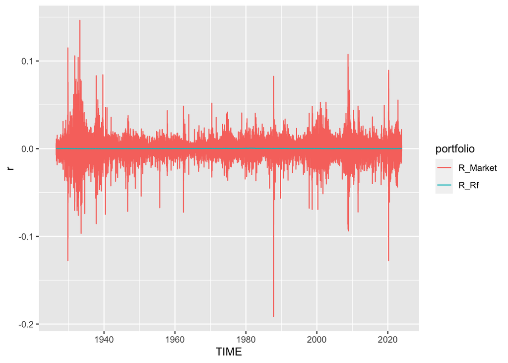

```r
Plot.TimeSeries(what=c("R_Rf","R_Market"))
```

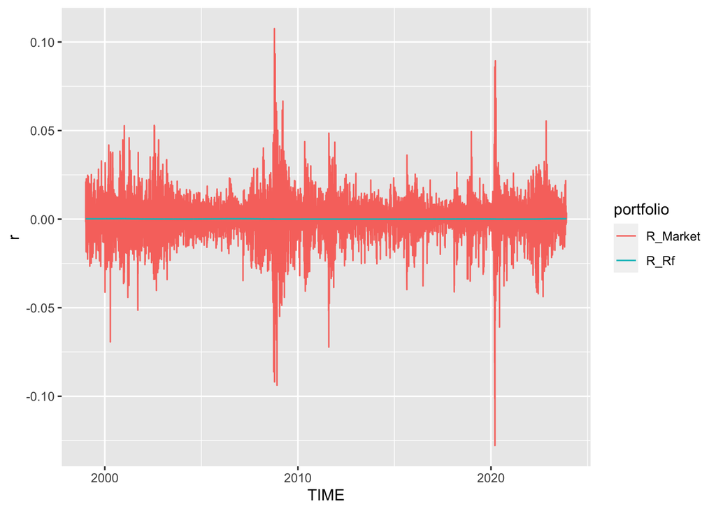

```r
Plot.TimeSeries(what=c("R_Rf","R_Market"),start="19990101")
```

Spot the pandemic’s arrival!

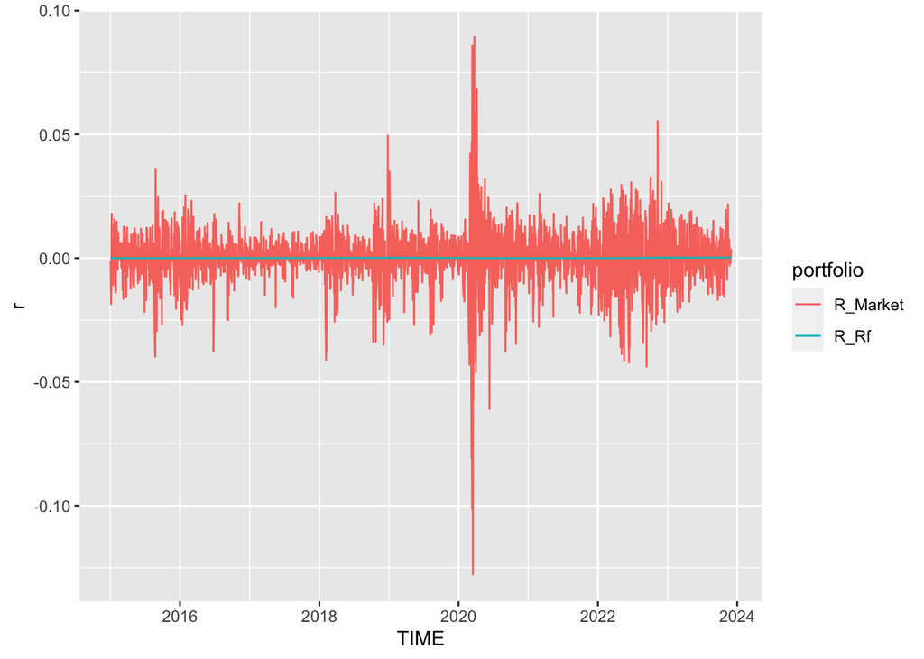

```r
Plot.TimeSeries(what=c("R_Rf","R_Market"),start="20150101")
```